# Part II - Fordgobike_Data_Explanatory_Presentation

## Edidiong Godwin Umoh

### Let's examine the duration of trips between stations and other features in the dataset that may affect it.

## Investigation Overview:

> The focus of this investigation is the duration of trips between stations in a Ford GoBike sharing event. The analysis will utilize a dataset containing information on bike trips between stations, including features such as member birth year, subscriber type, and longitude and latitude data. Additional columns, including distance between stations, speed, and member age, were generated to facilitate analysis.

## Dataset Overview:

> The dataset used for this investigation provides information on bike trips between stations in a bike sharing event. It includes features such as member birth year, subscriber type, longitude and latitude data, and other relevant trip details. To further facilitate the analysis, additional columns were generated, such as distance between stations, speed, and member age.

### Distribution of rides by User Type

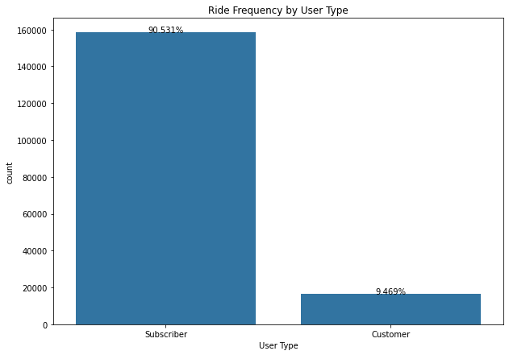

#### Based on the figure above, it can be observed that subscribers make up 90% of the total bike rides.

### Distribution of Rides by Days

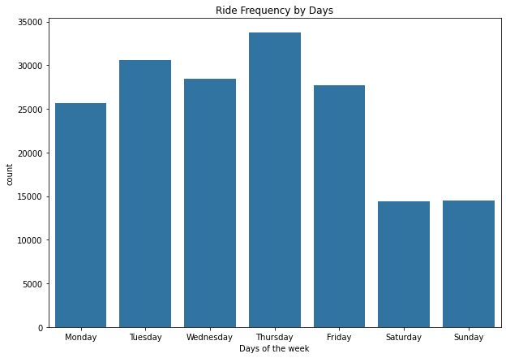

#### The majority of bike rides took place on Thursdays and Tuesdays, with the lowest number of trips occurring on weekends.

### Distribution of Rides by start hour

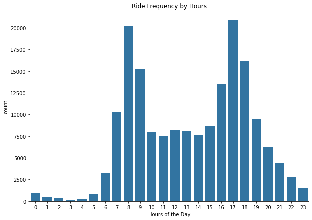

#### The higher frequency of bike rides during the morning (between 8 and 9 am) and evening (between 5 and 6 pm) may be associated with rush hour periods when people commute to and from work.

### Checking the distribution of the duration of the rides according to the day of ride

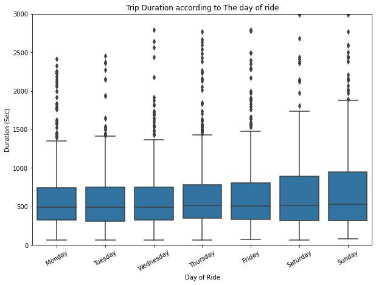

### Checking the distribution of the duration of the rides according to user type

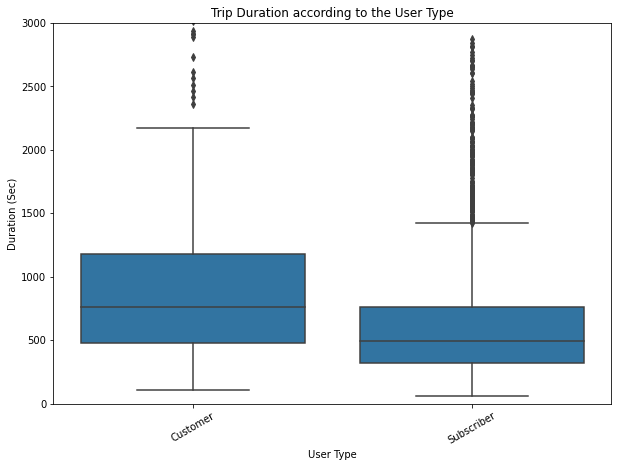

#### In general, customers have longer trip durations compared to subscribers.

### Duration of Trips across user types and days of the week

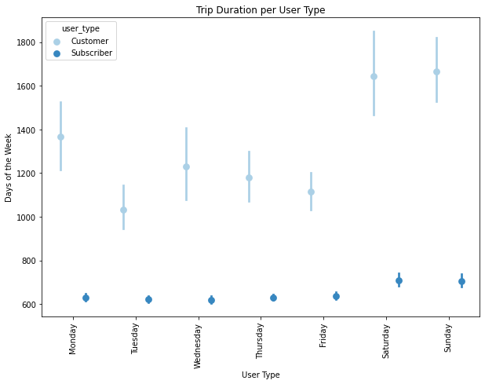